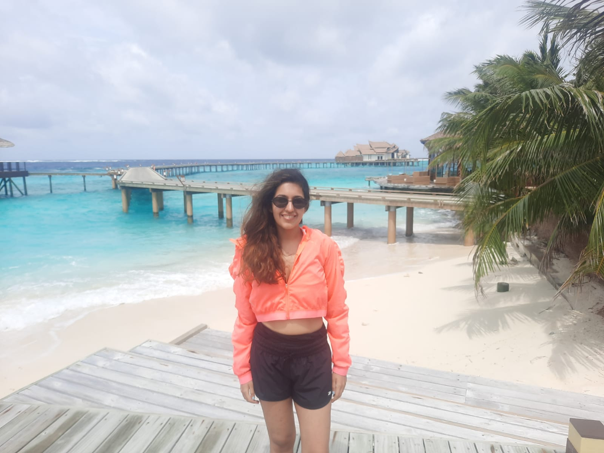

# Aanchal Dusija

[LinkedIn](https://www.linkedin.com/in/aanchal-dusija/) Email

Aanchal is a second-year graduate student pursuing an MS in Data Science & Analytics at Georgetown University. An enthusiastic analyst enjoys collecting, analyzing, interpreting large datasets, developing and improving processes. Strong knowledge of Microsoft Excel, Python Programming Language, R Programming Language, SQL, SPSS, Stata, PowerPoint, and other MS office tools along with proficiency at grasping new technical concepts quickly & utilizing them in a productive manner. I am passionate about my work because I love what I do. Always looking to challenge myself and grow further both professionally and personally. Always open for opportunities that will help me build a strong career foundation for future endeavours.

# **Education:**

**NMIMS University | Mumbai, India**

- B.Sc. Applied Statistics & Analytics | June 2016 - May 2019

**Meghnad Desai Academy of Economics | Mumbai, India**

- Postgraduation Diploma in Economics and Finance | August 2019 - August 2020

**Georgetown University | Washington DC, USA**

- M.S Data Science & Analytics | Aug 2022 - May 2024 (anticipated)

# **Experience:**

- GlobalFoundries | Digital Strategic Planning Intern | June 2023 - Aug 2023
- National Stock Exchange | Research Associate | Feb 2021 - Feb 2022
- National Stock Exchange | Research Intern | Jan 2020 - Mar 2020